# Finding founders - Making a maximum independent set

Alexandros Topaloudis

# Making an unrelated set

Making an unrelated set of individuals in our pedigree structure can be done through the beta kinship matrix in a graph approach. In this case we set individuals as nodes in a graph and create edges between individuals with beta kinship > x where x a cutoff we define as kinship allowed (ex. 0.0335). We then prune the graph to retain a set of independent individuals. Simply this can be done by choosing one individual at random, adding him to the independent set and then removing all individuals related with them. Continuing through the nodes, this would a give a maximal independent set but not the maximum independent set (biggest possible maximal independent set). Multiple iterations of the process each starting and progressing through the nodes in different order would give multiple sets and after an exhaustive search, the biggest set would be the maximum independent set. Even with ~350 nodes this process is painstakingly slow. The problem is solved in $O(n^22^n)$ by a brute force algorithm described above.

## Case 1 - manual modification and igraph

Lets start with the graph approach.

```r
library(kinship2)
library(igraph)
library(knitr)
library(corrplot)
library(SNPRelate)
dp <- read.delim('depth_stats_all.idepth')
ped <- read.csv('genetically_fixed_pedigree.csv')
pedk <- kinship(ped$id, ped$dadid,ped$momid)
metadata <- read.csv('refpanel_metadata.csv')
b <- read.table('swiss_beta_matrix.table')
b <- b[-which(rownames(b)=='877825F2'),-which(rownames(b)=='877825F2')]
rownames(b) <- metadata$NEWname[match(rownames(b),metadata$rawVCFname)]
kept <- read.csv('individuals_to_keep.csv')
b <- b[match(kept$NEWname,rownames(b)),match(kept$NEWname,rownames(b))]
```

We can make a graph using an adjacency matrix we basically translate a kinship matrix with values > cutoff –> 1 and values less than a cutoff to 0. Pairs of individuals with 1 in the matrix represent nodes connect with an edge while pairs with 0 are unconnected.

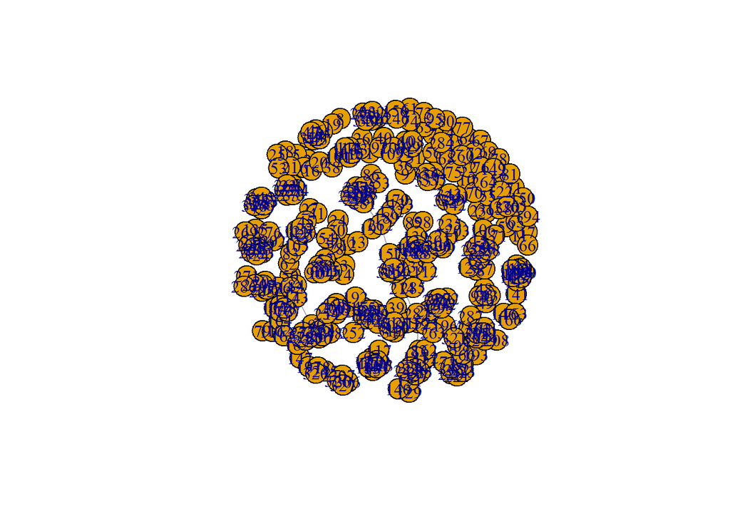

```r
kin2adj <- function(bmat, cutoff){
  edges <- data.frame(which(bmat > cutoff,arr.ind = T))
  tmp <- matrix(data=rep(0,nrow(bmat)^2), nrow=nrow(bmat), ncol=nrow(bmat))
  for(i in 1:nrow(edges)){tmp[edges$row[i],edges$col[i]]<- 1}
  diag(tmp) <- 0
  return(tmp)
}
g1 <- graph_from_adjacency_matrix(kin2adj(b,0.2),mode = 'undirected')
plot(g1)
```

```r
#mis <- largest_ivs(g1) # prohibitingly slow !!!
```

This function is as expected super slow so lets use the greedy algorithm of kinship2 and then verify with the beta matrix.

## Case 2 - kinship2 function pedigree.unrelated() + extra prunning

Kinship2 has a function that finds unrelated individuals in a pedigree using a greedy algorithm. However, this only gives a list of individuals with kinship == 0 using a pedigree input. This means that we need to provide a pedigree to the function and this pedigree should capture all our links. By construction the best we can do is the improved pedigree with genetic kinship. Lets see what this gives us…

```r
unrel1  <- pedigree.unrelated(pedigree(ped$id,ped$dadid,ped$momid,ped$sex),avail=ped$seq)
```

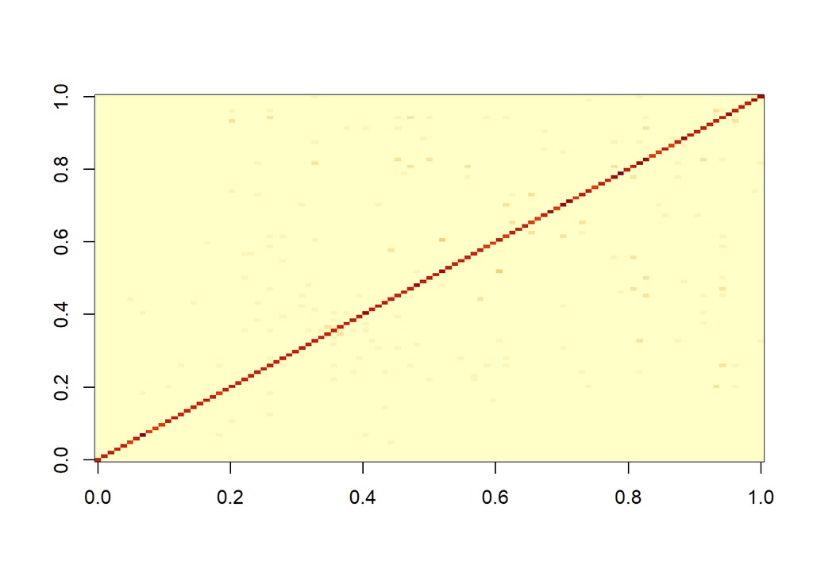

```r
bu <- as.matrix(b[rownames(b) %in% unrel1,rownames(b) %in% unrel1])
image(bu)
```

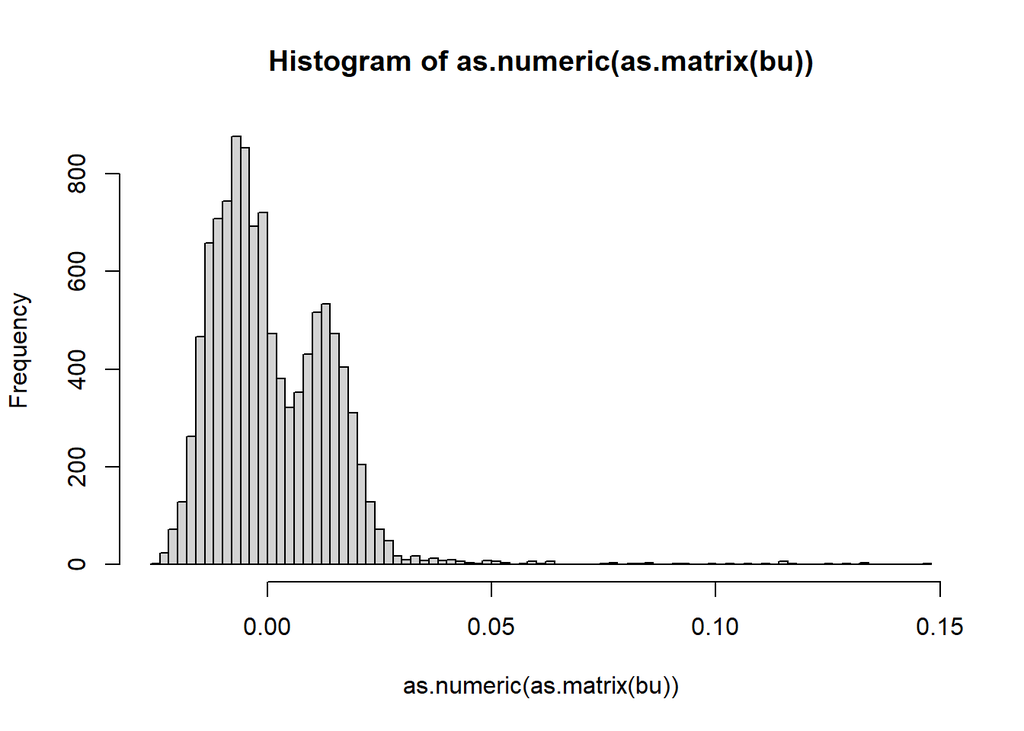

```r
diag(bu) <- 0
hist(as.numeric(as.matrix(bu)),breaks=100)
```

We still see that some individuals have links > 0 which is due to the incompleteness of our pedigree we fed to the kinship2 method. Now we can use a heuristic algorithm that removes individuals based on the # of > x links they have in the genomic matrix. At the same time we can take into account another layer of information ex. Depth and remove individuals sorted on # of links and depth to make sure we keep the highest depth individuals when possible.

```r
find.names <- function(beta.mat,cutoff){
  df <- data.frame('id1'=NULL,
                   'id2'=NULL,
                   'beta'=NULL)
  end <- nrow(beta.mat) - 1
  for(i in 1:end){
    start <- i + 1
    for(j in start:nrow(beta.mat)){
        if(beta.mat[i,j] >= cutoff){
          tmp.df <- data.frame('id1'=rownames(beta.mat)[i],
                               'id2'=rownames(beta.mat)[j],
                               'beta'=beta.mat[i,j])
          df <- rbind(df,tmp.df)
        }
      }
  }
  return(df)
}
make.ind.df <- function(pairs){
  tmp <- data.frame('id'=unique(c(pairs$id1,pairs$id2)))  # make individual df
  # make negative to match decreasing order !!!
  tmp$dp <- -dp$MEAN_DEPTH[match(metadata$rawVCFname[match(tmp$id,metadata$NEWname)],dp$INDV)] # add dp
  tmp$links <- 0 #  add link count
  for(i in 1:nrow(tmp)){
  tmp$links[i] <- sum(c(pairs$id1,pairs$id2)==tmp$id[i])
  }
  tmp <- tmp[order(tmp[,3],tmp[,2], decreasing = T),]
  return(tmp)
}
bu <- as.matrix(b[rownames(b) %in% unrel1,rownames(b) %in% unrel1])
pairs <- find.names(bu,0.1)
#kable(pairs,caption = 'pairs of unrelated that are related!')
related <- make.ind.df(pairs)
kable(related[1:10,],caption='related individuals with # of links' )
```

related individuals with # of links

|  | id | dp | links |
| --- | --- | --- | --- |
| 11 | M032051 | -9.63268 | 3 |
| 13 | M033660 | -9.44783 | 2 |
| 16 | M032002 | -29.14100 | 2 |
| 17 | M026459 | -8.29615 | 1 |
| 15 | M017312 | -8.73039 | 1 |
| 20 | M035431 | -9.13105 | 1 |
| 6 | M006413 | -9.44743 | 1 |
| 10 | M031581 | -9.69714 | 1 |
| 4 | M004500 | -10.05470 | 1 |
| 7 | M011816 | -10.25360 | 1 |

Now we can prune this list by removing the individuals with the biggest # of pairs and then recalculating this list and then removing again until list is empty.

```r
find.unrelated <- function(b,cutoff){
  bu <- b
  # initialize pairs
  pairs <- find.names(b,cutoff) # get pairs
  while(nrow(pairs)!=0){
    # find and remove worst candidate
    tmp <- make.ind.df(pairs)
    rm.ind <- tmp[1,1]
    bu <- bu[-match(rm.ind,rownames(bu)),-match(rm.ind,rownames(bu))]
    # recalculate pairs
    pairs <- find.names(bu,cutoff)
  }
  return(bu)
}
bu <- find.unrelated(bu,0.04)
dim(bu)
```

```
## [1] 80 80
```

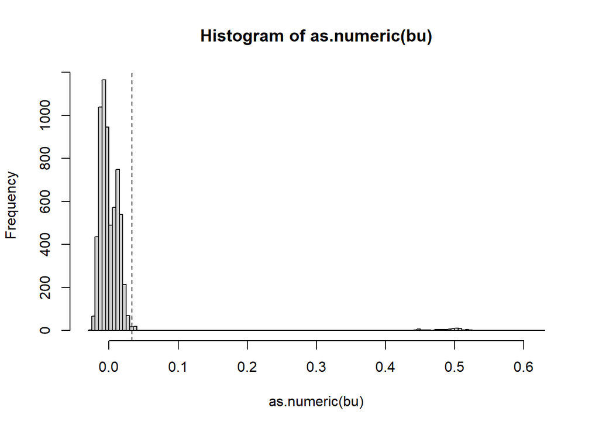

[figure not shown]

```r
hist(as.numeric(bu),breaks=100)
abline(v=0.0335,lty=2)
diag(bu) <- 0
corrplot(bu, tl.pos='n',diag = F,method = 'shade',is.corr = F)
#unrelated1 <- metadata[match(rownames(bu),metadata$NEWname),] # ~75 at 0.0335
#write.csv(unrelated1, 'unrelated_0335_kinship_100622.csv',quote=F,row.names = F)
```

## Europe.

And for the Europeans we can follow the same procedure, but here a strict cutoff on kinship will not be representative of true kinship (kinship was normalized on average of whole dataset but family structure and overrepresentation of CH has an impact). Specifically, the mean relatedness is a bit higher than expected from an unrelated sample and this means that we expect more negative values than normal. This should not impact our cutoff.

```r
geno <- snpgdsOpen('ref_panel_snps_f1_masked_maf05_miss05_LDpruned.gds')
beu <- snpgdsIndivBeta(geno,autosome.only = F)
```

```
## Individual Inbreeding and Relatedness (beta estimator):
## Excluding 0 SNP (monomorphic: TRUE, MAF: NaN, missing rate: NaN)
##     # of samples: 508
##     # of SNPs: 85,246
##     using 1 thread
## Individual Beta:    the sum of all selected genotypes (0,1,2) = 51312622
## CPU capabilities: Double-Precision SSE2
## Tue Jun 14 14:27:12 2022    (internal increment: 63616)
##
[..................................................]  0%, ETC: ---
[==================================================] 100%, completed, 1s
## Tue Jun 14 14:27:13 2022    Done.
```

```r
beur <- snpgdsIndivBetaRel(beu,mean(beu$beta))
indx1 <- match(metadata$rawVCFname[metadata$pop !='CH'], beur$sample.id)
eub <- beur$beta[indx1, indx1]
rownames(eub) <- beur$sample.id[indx1]
nrow(eub)
```

```
## [1] 156
```

```r
hist(eub,breaks=100)
abline(v=0.2)
abline(v=0.1)
abline(v=0.0335)
nrow(find.unrelated(eub,0.2))
```

```
## [1] 150
```

```r
nrow(find.unrelated(eub,0.12))
```

```
## [1] 122
```

```r
nrow(find.unrelated(eub,0.0335))
```

```
## [1] 50
```

[figure not shown]